# TP1 statistiques inférentielles

Arthur Zucker

10/15/2019

# Exercice 1

Le test de shapiro est un test statistique nous permettant d’accepter ou rejeter l’hypothèse selon laquelle l’echantillon peut être approximé par une loi gaussienne iid. Ainsi on calcul la $p-value$ nous permettant, selon le parametre $\alpha$ que l’on choisi de rejeter ou ne pas rejeter l’hypothèse $H_{0}$

```r
x=c(3.7,3.4,4.2,3.8,3.9,4,3.5,3.6,4.3,3.3)
shapiro.test(x)
```

```
##
##  Shapiro-Wilk normality test
##
## data:  x
## W = 0.96908, p-value = 0.8822
```

On a pour $\alpha = 0.05 , p>\alpha$ on ne rejette donc pas l’hypothèse $H_{0}$ et on suppose que par défaut les $X_{i}$ sont gaussiens. On effectue maintenant la statistique de test sur l’hyôthèse $H_{0}:= \mu < 4$ :

```r
t.test(x,mu=4,alternative = 'less')
```

```
##
##  One Sample t-test
##
## data:  x
## t = -2.1809, df = 9, p-value = 0.02855
## alternative hypothesis: true mean is less than 4
## 95 percent confidence interval:
##      -Inf 3.963324
## sample estimates:
## mean of x
##      3.77
```

On peut retrouver le resultat sur l’intervalle de confiance en utilisant la formule suivante, on a le quantile d’ordre $95\%$ parce qu’on prend une loi unilateral et non bi-laterale.

```r
n=length(x)
#borne sup IC :
mean(x)+qt(0.95,n-1)*sd(x)/sqrt(n)
```

```
## [1] 3.963324
```

# Exercice 2

## Question 1

Alternative `=less` est utilisé parce que l’hypothèse $H_{0}:= \sigma<0.25$. Avec a `p-value`on cherche à savoir si on rejette ou pas $H_{0}$. Ici pour $\alpha = 0.05$ on ne rejette pas $H_{0}$ et on suppose par défaut que le médicament n’est pas efficace. (p-value>$\alpha$)

```r
prop.test(13,55,0.25,alternative = "less")
```

```
##
##  1-sample proportions test with continuity correction
##
## data:  13 out of 55, null probability 0.25
## X-squared = 0.0060606, df = 1, p-value = 0.469
## alternative hypothesis: true p is less than 0.25
## 95 percent confidence interval:
##  0.0000000 0.3513353
## sample estimates:
##         p
## 0.2363636
```

```r
# si test exact :
binom.test(13,55,0.25,alternative="less")
```

```
##
##  Exact binomial test
##
## data:  13 and 55
## number of successes = 13, number of trials = 55, p-value = 0.4794
## alternative hypothesis: true probability of success is less than 0.25
## 95 percent confidence interval:
##  0.0000000 0.3492993
## sample estimates:
## probability of success
##              0.2363636
```

## Question 2

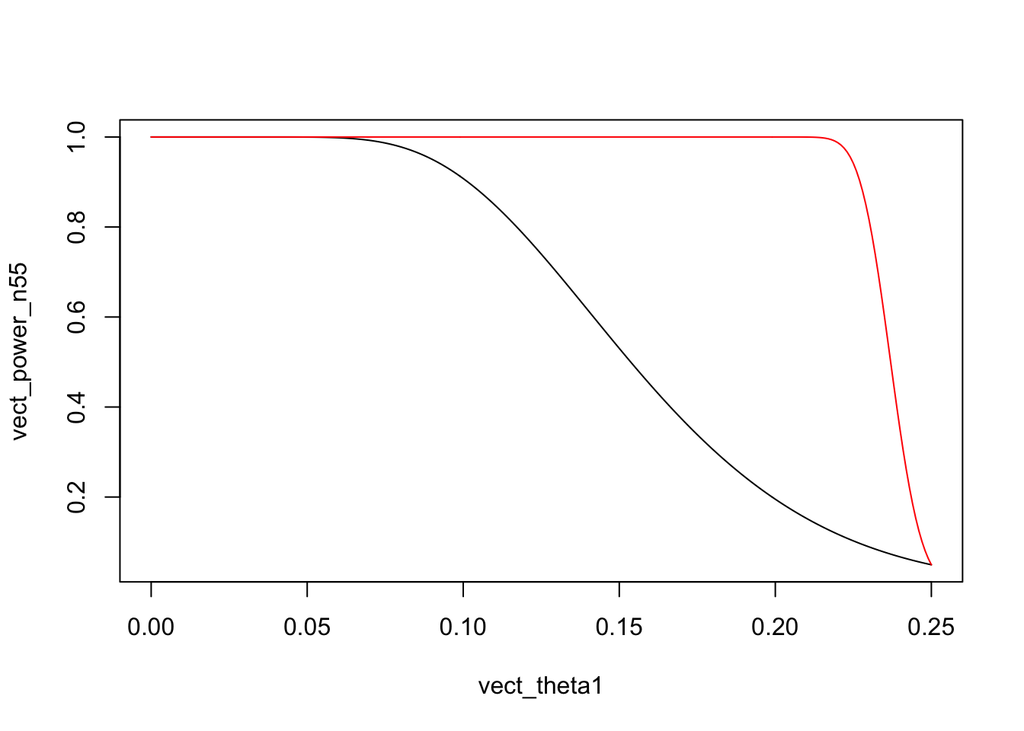

```r
#courbe puissance à la main
n=55
theta1=0.23
puissance=function(theta1,n)
{ power=pnorm((-1.65*sqrt(0.25*0.75/n)+0.25-theta1)/sqrt(theta1*(1-theta1)/n))
 return(power)
}
vect_theta1=seq(0, 0.25, by=0.001)
vect_power_n55=puissance(vect_theta1,n=55)
vect_power_n3000=puissance(vect_theta1,n=3000)
plot(vect_theta1,vect_power_n55,type="l")
lines(vect_theta1,vect_power_n3000,type="l",col=2)
```

# Exercice 3

## Question 1

Pour calculer une puissance on se met sous $H_1$. Delta est la différence entre les deux hypothèses?

```r
n = 40
mu = 6.4
power.t.test(n,0.4,sd = 1.2,type = 'one.sample',alternative = 'one.sided')
```

```
##
##      One-sample t test power calculation
##
##               n = 40
##           delta = 0.4
##              sd = 1.2
##       sig.level = 0.05
##           power = 0.6651413
##     alternative = one.sided
```

## Question 2

Observons le graphe de la puissance :

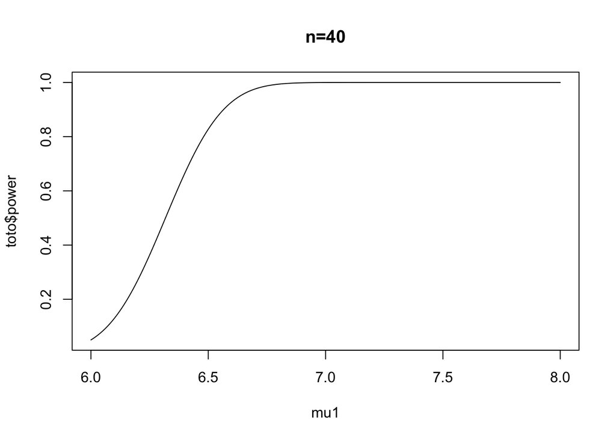

```r
mu1=seq(6,8 ,by=0.01)
delta=mu1-6
toto=power.t.test(n,delta,sd = 1.2,type = 'one.sample',alternative = 'one.sided')
plot(mu1,toto$power, type='l',main="n=40")
```

## Question 3

```r
power.t.test(power=0.9,delta = 0.4,sd = 1.2,type = 'one.sample',alternative = 'one.sided')
```

```
##
##      One-sample t test power calculation
##
##               n = 78.44742
##           delta = 0.4
##              sd = 1.2
##       sig.level = 0.05
##           power = 0.9
##     alternative = one.sided
```

# Exercice 4

## Question 1

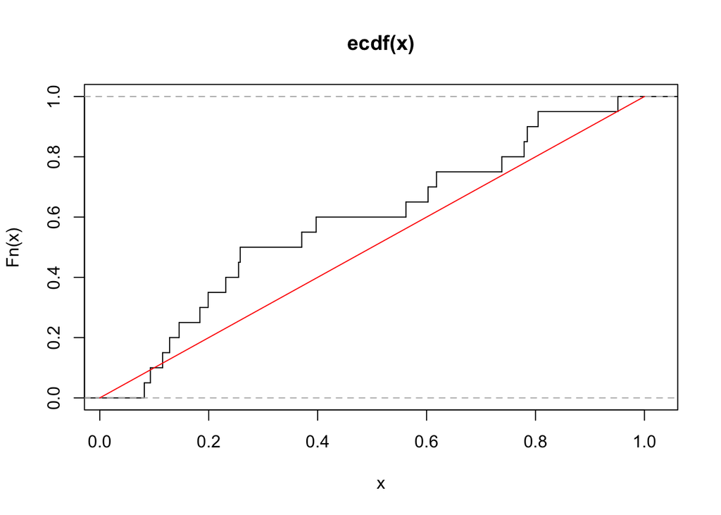

```r
n=20
# échantillon de variables aléatoires de loi uniforme sur [0,1] :
x = runif(n)

# fonction de répartition empirique :
fn=ecdf(x)
plot(fn, verticals=TRUE, do.points=FALSE)
lines(seq(0,1,0.01),punif(seq(0,1,0.01),0,1),col = 2)
```

```r
# superposer la fonctin de répartition de la loi  uniforme sur [0,1]

# test de Kolmagorov Smirnov
ks.test(x,"punif")
```

```
##
##  One-sample Kolmogorov-Smirnov test
##
## data:  x
## D = 0.24223, p-value = 0.1616
## alternative hypothesis: two-sided
```

# Exo 5

Les droites d’Henr d’équation suivante : $y = \frac{1}{\sigma}x-\frac{\mu}{\sigma}$.

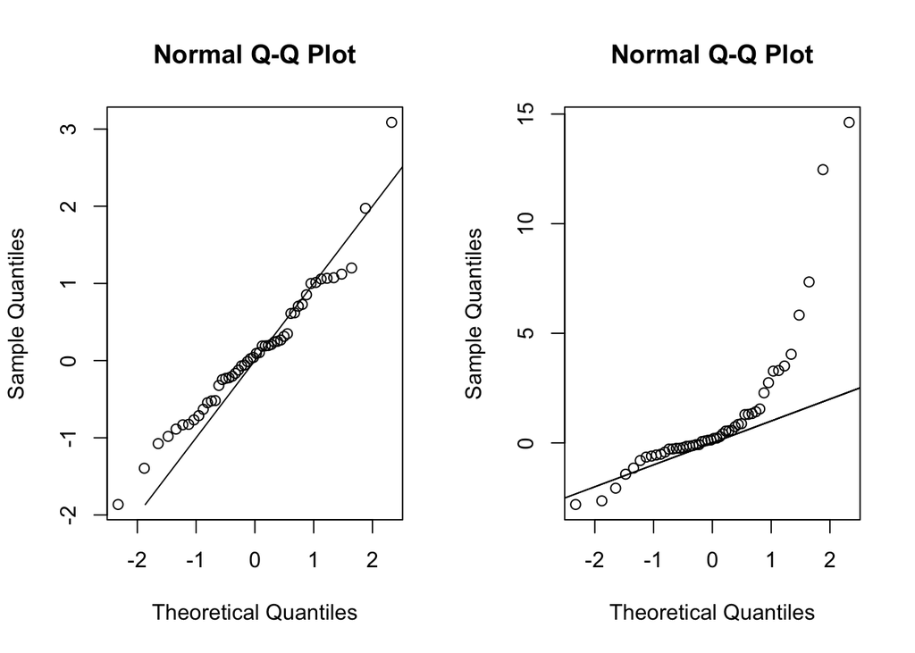

```r
# simulation des échantillons :
x= rnorm(50)
y= rcauchy(50)

# Droites de Henry :

par(mfrow=c(1,2))
qqnorm(x)
lines(x,x)
qqnorm(y)
lines(y,y)
```

```r
# test de Kolmagorov Smirnov
ks.test(y,"pnorm")
```

```
##
##  One-sample Kolmogorov-Smirnov test
##
## data:  y
## D = 0.20203, p-value = 0.0289
## alternative hypothesis: two-sided
```

```r
# test de Shapiro :
shapiro.test(y)
```

```
##
##  Shapiro-Wilk normality test
##
## data:  y
## W = 0.70075, p-value = 8.535e-09
```

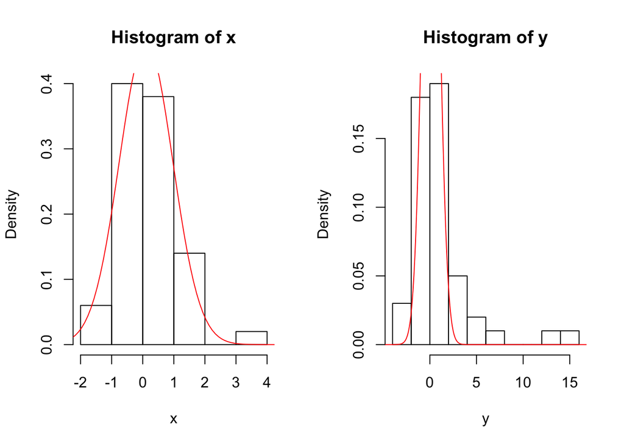

```r
# un peu de stat descriptive :
par(mfrow=c(1,2))
hist(x,prob=TRUE)
abscisses=seq(min(x)-10,max(x)+10,0.1)
lines(abscisses,dnorm(abscisses,mean(x),sd(x)),col=2)
hist(y,prob=TRUE)
abscisses=seq(min(y)-10,max(y)+10,0.1)
lines(abscisses,dnorm(abscisses,mean(x),sd(x)),col=2)
```